# Basic CGM Graphs

Andy Choens

# Objectives

This is quick demonstration of graphing Continuous Glucose Monitor (CGM) data from Nightscout data using R. Graphing in R . . . is complicated. As with many things, R is incredibly powerful, but complicated. Today’s post will use the ggplot2 (ggplot) graphic system. For many reasons, I actually prefer the ggvis system, but it doesn’t work as well as ggplot on the Windows platform. The dashboard I’m working on will probably use ggvis, but I wanted to publish this code because A) I have it and B) I wanted to demonstrate some code that works well on Windows.

Objectives are:

1. Load data.
2. Clean-Up / Process the data (Data Munging!) to prepare it for use.
3. Use R and ggplot to produce a series of graphs of Karen’s blood glucose levels.
4. Compare patterns seen in the graphs to what we learned previously when we looked at some descriptive statistics of Karen’s blood glucose data.

All code is shown and documented.

```r
## Dependencies ----------------------------------------------------------------
## If any of these fail, run the following (capitalization counts):
## install.packages("name_of_package")
library(devtools)
library(dplyr)
library(ggplot2)
library(pander)
load_all()

## Config ----------------------------------------------------------------------

## Prevents pander from wrapping the table @ 80 chars.
panderOptions('table.split.table', Inf)
```

# Data Import & Munging

The following code chunk imports the most recent CSV file available in the data folder and stores it in a data frame called “entries”. This name is used for consistency with Nightscout data structures.

```r
## Import data------------------------------------------------------------------
## Retrieves a list of CSV files in the data dir.
## Imports the most recent file, assuming the file naming schema is followed.
data(entries)

## Data Munging ----------------------------------------------------------------

## We only want the SGV rows.
entries <- entries %>%
    filter(type == "sgv")

## Week Labels - Useful labels we will be to aggregate by later.
entries$wk_lbl <- NA
entries$wk_lbl[ entries$date >= '2015-06-28' & entries$date <'2015-07-05' ] <- 'Week 1: June 28 - July 04'
entries$wk_lbl[ entries$date >= '2015-07-05' & entries$date <'2015-07-12' ] <- 'Week 2: July 05 - July 11'
entries$wk_lbl[ entries$date >= '2015-07-12' & entries$date <'2015-07-19' ] <- 'Week 3: July 12 - July 18'
entries$wk_lbl[ entries$date >= '2015-07-19' & entries$date <'2015-07-26' ] <- 'Week 4: July 19 - July 25'
```

If you use Nightscout, be aware that the rate of blood glucose change shown here is more dramatic than that shown by Nightscout. Nightscout displays the log of the Y-Axis values. The graph below graphs the raw values. The Nightscout developers have good reasons for doing this and I do not disagree with them. But, to understand the dynamic and often rapid nature of blood glucose change, I think plotting the raw values is appropriate. Karen’s brother, who is less volatile because he does not have gastroparesis, would look very different from what I am about to show you.

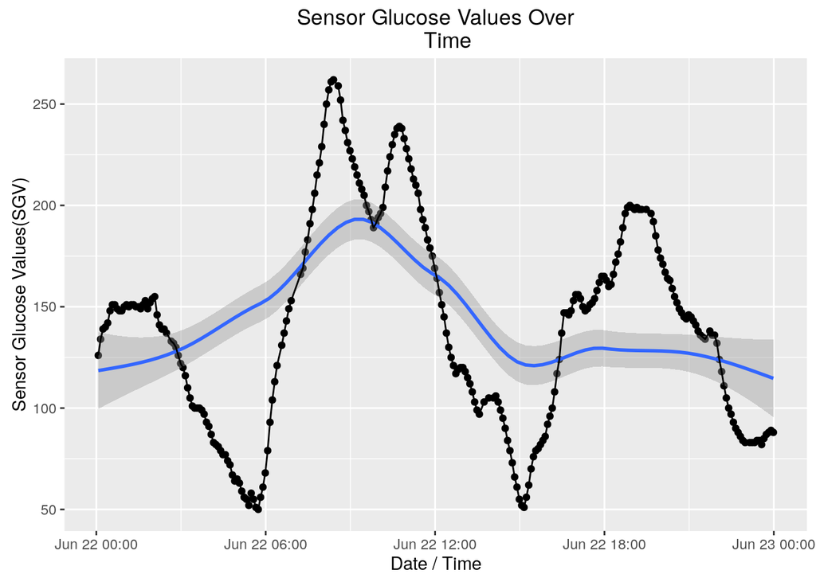

```r
entries %>% filter(date >= '2015-06-22' & date < '2015-06-23') %>%
    select(date, sgv) %>% ggplot(data=., aes(x = date, y=sgv)) +
    geom_point() + geom_smooth() + geom_line() + labs(x="Date / Time",
    y="Sensor Glucose Values(SGV)", title="Sensor Glucose Values Over
    Time")
```

For stats nerds, the blue line is a loess curve. Medically, this was a pretty good day. Karen peaked around 250 and never dipped below 50. But notice, she was never stable. Gastroparesis and stress are evil opponents. This wasn’t a bad day, but she was never really stable. She did not have even a single time where her blood glucose levels were “normal” and stable. She passed through “normal” several times, on her way to hyper and hypo glycemic episodes.

Karen has observed that her patterns on weekdays are different from her patterns on weekends. The following graph was not chosen at random. I selected this to highlight the difference Karen feels exists betwen her weekdays and her weekends.

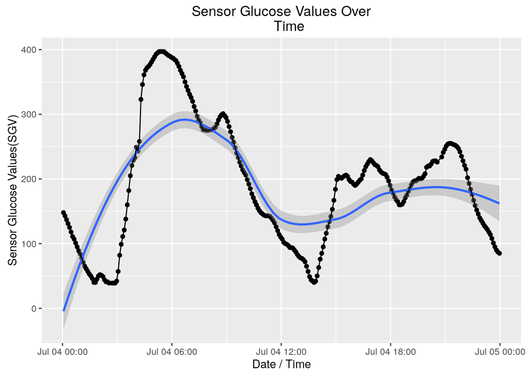

```r
entries %>% filter(date >= '2015-07-04' & date < '2015-07-05') %>%
    select(date, sgv) %>% ggplot(data=., aes(x = date, y=sgv)) +
    geom_point() + geom_smooth() + geom_line() + labs(x="Date / Time",
    y="Sensor Glucose Values(SGV)", title="Sensor Glucose Values Over
    Time")
```

Look at her afternoon (the right side of the graph). Yes, she continues to vary. That’s diabetes. And yes, she had a bad hyperglycemic episode in the AM but look at her stability in the afternoon. That sort of relative stability is unusual for Karen during a weekday.